# EDS 213 Assignment 2

Scout Leonard

10/7/2021

# [Class Assignment](https://brunj7.github.io/EDS-213-metadata/week_2.html): Using APIs Lab

## USGS `dataretrieval` R package to retrieve hydrological data

### Exercise 1

Start a new Markdown document to plot the discharge time-series for the Ventura River from 2019-10-01 to 2020-10-05.

```r
siteNumber <- "11118500"
paramaterCd <- "00060"
startDate <- "2019-10-01"
endDate <- "2020-10-05"

ventura_discharge <- readNWISdv(siteNumber, paramaterCd, startDate, endDate)
```

```r
# names(ventura_discharge) #looking at the column names

renamed_ventura_discharge <- renameNWISColumns(ventura_discharge) #rename columns
```

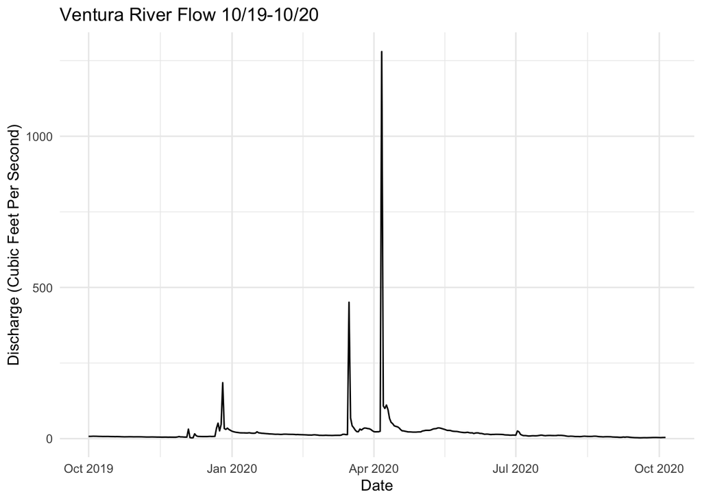

```r
ventura_flow_over_time <- ggplot(data = renamed_ventura_discharge, aes(x = Date, y = Flow)) +
  geom_line() +
  labs(title = "Ventura River Flow 10/19-10/20",
       y = "Discharge (Cubic Feet Per Second)") +
  theme_minimal()

ventura_flow_over_time
```

### Bonus

How would you try to determine when this stream gauge record started using the API?

```r
siteNumber1 <- "11118500"
paramaterCd1 <- "00060"
startDate1 <- "" #by including no date, I call data from the very beginning of when data was collected at this site
endDate1 <- "2020-10-05"

find_start_date <- readNWISdv(siteNumber1, paramaterCd1, startDate1, endDate1)

summary(find_start_date$Date) #using summary, I can find the minimum date in the Data column, which is the start date
```

```
##         Min.      1st Qu.       Median         Mean      3rd Qu.         Max.
## "1929-10-01" "1952-07-02" "1975-04-04" "1975-04-04" "1998-01-03" "2020-10-05"
```

*Using the API, I determined that the stream gauge data started October 1st, 1929.*

## `metajam`

The `metajam` R package relies on the dataONE API to download data and metadata into your R Environment. It is currently supporting KNB, ADC and EDI repositories because they rely on the metadata standard EML.

### Exercise 2

Let’s determine what percentage of Alaskan household are speaking only English!

```r
#set inputs
data_obj <- "https://cn.dataone.org/cn/v2/resolve/urn:uuid:7fc6f6db-c5ea-426a-a743-1f2edafb43b8"

path <- "~/Documents/MEDS/term_2/eds213/assignments/eds213_assignment2"

#download data and metadata
download_d1_data(data_obj, path)
```

```r
alaska_data <- read_d1_files(folder_path = "doi_10.5063_F1CJ8BPH__household_language__csv")
```

```r
alaska_summary_metadata <- alaska_data$summary_metadata

alaska_attribute_metadata <- alaska_data$attribute_metadata
```

```r
household_languages <- alaska_data$data
```

```r
alaska_english <- household_languages %>%
  filter(Year >= 2009 & Year <= 2015)

mean_by_year <- alaska_english %>%
  mutate(percent_english_speaking = 100*(speak_only_english / total), na.rm = TRUE) %>%
  group_by(Year) %>%
  summarize(average_eng_percent_byyear = mean(percent_english_speaking, na.rm = TRUE))
```

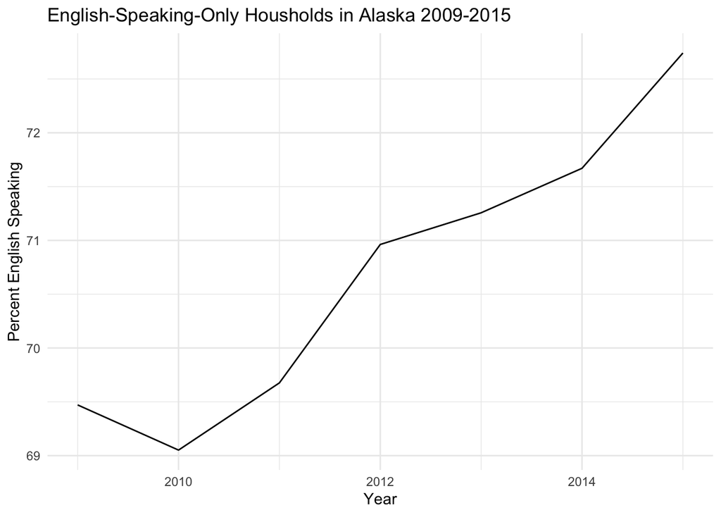

```r
per_eng_plot <- ggplot(data = mean_by_year, aes(x = Year, y = average_eng_percent_byyear)) +
  geom_line() +
  labs(title = "English-Speaking-Only Housholds in Alaska 2009-2015",
       y = "Percent English Speaking") +
  theme_minimal()

per_eng_plot
```

The percent of Alaskan households that speak English only has **increased** between 2009 and 2015.

# [Homework: Assignment 2](https://brunj7.github.io/EDS-213-metadata/assignments_w2.html)

## Assignment 2.1

1.) Add the [Santa Paula Creek](https://waterdata.usgs.gov/nwis/uv?site_no=11113500) gauge to exercise we did in class

```r
siteNumber_1 <- "11113500"
paramaterCd_1 <- "00060"
startDate_1 <- ""
endDate_1 <- ""

spcreek_discharge_1 <- readNWISdv(siteNumber_1, paramaterCd_1, startDate_1, endDate_1)
```

2.) What is the best way to query multiple sites using this R package?

**The best way to query multiple sites using this R package is to assign the siteNumbers argument a vector with multiple site numbers of interest.**

3.) Create a plot showing any stream flow response to the rain of last night (10/04). Determine at what time did the stream flow peaked (if any) at the two locations?

```r
siteNumber_3 <- "11113500"
paramaterCd_3 <- "00060"
startDate_3 <- "2021-10-03"
endDate_3 <- "2021-10-05"

spcreek_discharge_3 <- readNWISuv(siteNumber_3, paramaterCd_3, startDate_3, endDate_3)
spcreek_discharge_3 <- renameNWISColumns(spcreek_discharge_3)
```

```r
siteNumber_4 <- "11118500"
paramaterCd_4 <- "00060"
startDate_4 <- "2021-10-03"
endDate_4 <- "2021-10-05"

ventura_discharge_4 <- readNWISuv(siteNumber_4, paramaterCd_4, startDate_4, endDate_4)
ventura_discharge_4 <- renameNWISColumns(ventura_discharge_4)
```

```r
creeks_combined <- rbind(spcreek_discharge_3, ventura_discharge_4)

#check to make sure the data I want are in this new dataframe
unique(creeks_combined$site_no)
```

```
## [1] "11113500" "11118500"
```

```r
summary(creeks_combined$dateTime)
```

```
##                  Min.               1st Qu.                Median
## "2021-10-03 07:00:00" "2021-10-04 01:13:45" "2021-10-04 19:12:30"
##                  Mean               3rd Qu.                  Max.
## "2021-10-04 19:11:15" "2021-10-05 13:11:15" "2021-10-06 07:45:00"
```

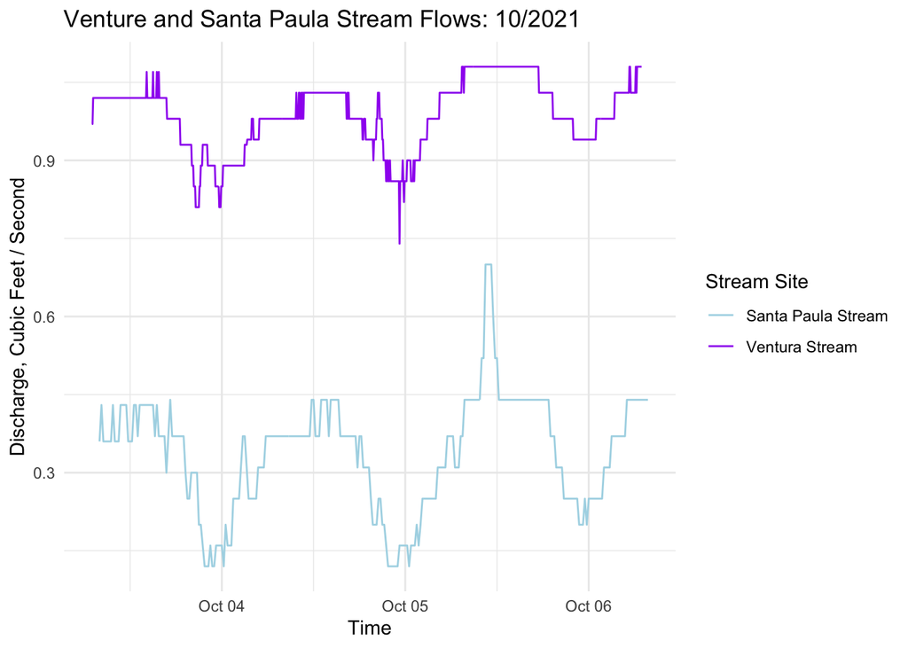

```r
creek_comparison_plots <- ggplot(data = creeks_combined, aes(x = dateTime, y = Flow_Inst)) +
  geom_line(aes(color = site_no)) +
  labs(color = "Stream Site",
       x = "Time",
       y = "Discharge, Cubic Feet / Second",
       title = "Venture and Santa Paula Stream Flows: 10/2021")+
  scale_color_manual(labels = c("Santa Paula Stream", "Ventura Stream"), values = c("lightblue", "purple")) +
  theme_minimal()

creek_comparison_plots
```

```r
summary(spcreek_discharge_3$Flow_Inst) #max flow is 0.7000
```

```
##    Min. 1st Qu.  Median    Mean 3rd Qu.    Max.
##  0.1200  0.2500  0.3700  0.3384  0.4300  0.7000
```

```r
max_times_sp <- spcreek_discharge_3 %>%
  filter(Flow_Inst == 0.7000) %>%
  gt()

max_times_sp
```

| agency_cd | site_no | dateTime | Flow_Inst | Flow_Inst_cd | tz_cd |
| --- | --- | --- | --- | --- | --- |
| USGS | 11113500 | 2021-10-05 10:30:00 | 0.7 | P | UTC |
| USGS | 11113500 | 2021-10-05 10:45:00 | 0.7 | P | UTC |
| USGS | 11113500 | 2021-10-05 11:00:00 | 0.7 | P | UTC |
| USGS | 11113500 | 2021-10-05 11:15:00 | 0.7 | P | UTC |

```r
summary(ventura_discharge_4$Flow_Inst) #max flow is 1.0800
```

```
##    Min. 1st Qu.  Median    Mean 3rd Qu.    Max.
##  0.7400  0.9400  0.9800  0.9883  1.0300  1.0800
```

```r
max_times_ventura <- ventura_discharge_4 %>%
  filter(Flow_Inst == 1.0800) %>%
  gt()

max_times_ventura
```

| agency_cd | site_no | dateTime | Flow_Inst | Flow_Inst_cd | tz_cd |
| --- | --- | --- | --- | --- | --- |
| USGS | 11118500 | 2021-10-05 07:25:00 | 1.08 | P | UTC |
| USGS | 11118500 | 2021-10-05 07:30:00 | 1.08 | P | UTC |
| USGS | 11118500 | 2021-10-05 07:35:00 | 1.08 | P | UTC |
| USGS | 11118500 | 2021-10-05 07:45:00 | 1.08 | P | UTC |
| USGS | 11118500 | 2021-10-05 07:50:00 | 1.08 | P | UTC |
| USGS | 11118500 | 2021-10-05 07:55:00 | 1.08 | P | UTC |
| USGS | 11118500 | 2021-10-05 08:00:00 | 1.08 | P | UTC |
| USGS | 11118500 | 2021-10-05 08:05:00 | 1.08 | P | UTC |
| USGS | 11118500 | 2021-10-05 08:10:00 | 1.08 | P | UTC |
| USGS | 11118500 | 2021-10-05 08:15:00 | 1.08 | P | UTC |
| USGS | 11118500 | 2021-10-05 08:20:00 | 1.08 | P | UTC |
| USGS | 11118500 | 2021-10-05 08:25:00 | 1.08 | P | UTC |
| USGS | 11118500 | 2021-10-05 08:30:00 | 1.08 | P | UTC |
| USGS | 11118500 | 2021-10-05 08:35:00 | 1.08 | P | UTC |
| USGS | 11118500 | 2021-10-05 08:40:00 | 1.08 | P | UTC |
| USGS | 11118500 | 2021-10-05 08:45:00 | 1.08 | P | UTC |
| USGS | 11118500 | 2021-10-05 08:50:00 | 1.08 | P | UTC |
| USGS | 11118500 | 2021-10-05 08:55:00 | 1.08 | P | UTC |
| USGS | 11118500 | 2021-10-05 09:00:00 | 1.08 | P | UTC |
| USGS | 11118500 | 2021-10-05 09:05:00 | 1.08 | P | UTC |
| USGS | 11118500 | 2021-10-05 09:10:00 | 1.08 | P | UTC |
| USGS | 11118500 | 2021-10-05 09:15:00 | 1.08 | P | UTC |
| USGS | 11118500 | 2021-10-05 09:20:00 | 1.08 | P | UTC |
| USGS | 11118500 | 2021-10-05 09:25:00 | 1.08 | P | UTC |
| USGS | 11118500 | 2021-10-05 09:30:00 | 1.08 | P | UTC |
| USGS | 11118500 | 2021-10-05 09:35:00 | 1.08 | P | UTC |
| USGS | 11118500 | 2021-10-05 09:40:00 | 1.08 | P | UTC |
| USGS | 11118500 | 2021-10-05 09:45:00 | 1.08 | P | UTC |
| USGS | 11118500 | 2021-10-05 09:50:00 | 1.08 | P | UTC |
| USGS | 11118500 | 2021-10-05 09:55:00 | 1.08 | P | UTC |

[output cut: 101 more lines]

**Maximum flow for the Ventura River for these data occurs between 10/05/21 at 7:25 am and 10/06/21 at 6:55 am.**